# Credit Card Customer Segmentation for AllLife Bank

#### Data Analysis and Modeling by: Varun Kulkarni (kulkarnivarun@outlook.com)

## Objective:

To identify different segments in the existing customer based on their spending patterns as well as past interaction with the bank.

## Data Source

Credit Card Customer Data.xlsx

## Tasks

- Exploratory Data Analysis
- K-Means Clustering
- Hierarchical Clustering
- Silhouette Scores for K-Means and Hierarchical Clustering
- Comparison Between K-Means and Hierarchical Clusters
- Analyzing Clusters - Finding Answers to Key Questions

```python
# Import required libraries
import pandas as pd
import numpy as np
import matplotlib.pyplot as plt
import seaborn as sns
import warnings
from IPython.core import display as disp

# Import relevant models and metrics from sklearn
from sklearn.cluster import KMeans
from sklearn.metrics import silhouette_score

# Import utilities from scipy
from scipy.stats import zscore, skew
from scipy.cluster.hierarchy import cophenet, dendrogram, linkage, fcluster
from scipy.spatial.distance import pdist, cdist

# Environment and global settings
%matplotlib inline
sns.set(color_codes=True)
warnings.filterwarnings('ignore')
SEED=42 # seed for random state for splitting data and models.
```

## Exploratory Data Analysis

```python
orig_df = pd.read_excel('Credit Card Customer Data.xlsx')
orig_df.head()
```

|  | Sl_No | Customer Key | Avg_Credit_Limit | Total_Credit_Cards | Total_visits_bank | Total_visits_online | Total_calls_made |
| --- | --- | --- | --- | --- | --- | --- | --- |
| 0 | 1 | 87073 | 100000 | 2 | 1 | 1 | 0 |
| 1 | 2 | 38414 | 50000 | 3 | 0 | 10 | 9 |
| 2 | 3 | 17341 | 50000 | 7 | 1 | 3 | 4 |
| 3 | 4 | 40496 | 30000 | 5 | 1 | 1 | 4 |
| 4 | 5 | 47437 | 100000 | 6 | 0 | 12 | 3 |

```python
# Serial Number and custoomer key may not be helpful going further.
# Let's drop serial number and customer key / Id but retain it in the original data.
data_df = orig_df.drop(columns=['Sl_No', 'Customer Key'])

# Let's convert column names to lower case for simplicity and uniformity.
column_map = {x:x.lower() for x in data_df.columns.to_list()}
data_df.rename(columns=column_map, inplace=True)

# Shape of the dataset
print("There are {0} records and {1} variables of interest.".format(data_df.shape[0], data_df.shape[1]))

# Check for null values
if data_df.isnull().values.any():
    print("Null values found!")
else:
    print("No null values found.")

# Check for NA values
if data_df.isna().values.any():
    print("NA values found!")
else:
    print("No NA values found.")

# Check for duplicated values
print("Number of duplicated records: ", data_df.duplicated().sum())
```

```
There are 660 records and 5 variables of interest.
No null values found.
No NA values found.
Number of duplicated records:  11
```

#### *Observations on given data*:

- No null or missing values found.
- Zero seems to be legitimate value.
- There seems to be duplicate records to be handled.

```python
# Let's look at the data types and other related details
data_df.info()
```

```
<class 'pandas.core.frame.DataFrame'>
RangeIndex: 660 entries, 0 to 659
Data columns (total 5 columns):
 #   Column               Non-Null Count  Dtype
---  ------               --------------  -----
 0   avg_credit_limit     660 non-null    int64
 1   total_credit_cards   660 non-null    int64
 2   total_visits_bank    660 non-null    int64
 3   total_visits_online  660 non-null    int64
 4   total_calls_made     660 non-null    int64
dtypes: int64(5)
memory usage: 25.9 KB
```

```python
# Let's look at the five point summary
data_df.describe().T
```

|  | count | mean | std | min | 25% | 50% | 75% | max |
| --- | --- | --- | --- | --- | --- | --- | --- | --- |
| avg_credit_limit | 660.0 | 34574.242424 | 37625.487804 | 3000.0 | 10000.0 | 18000.0 | 48000.0 | 200000.0 |
| total_credit_cards | 660.0 | 4.706061 | 2.167835 | 1.0 | 3.0 | 5.0 | 6.0 | 10.0 |
| total_visits_bank | 660.0 | 2.403030 | 1.631813 | 0.0 | 1.0 | 2.0 | 4.0 | 5.0 |
| total_visits_online | 660.0 | 2.606061 | 2.935724 | 0.0 | 1.0 | 2.0 | 4.0 | 15.0 |
| total_calls_made | 660.0 | 3.583333 | 2.865317 | 0.0 | 1.0 | 3.0 | 5.0 | 10.0 |

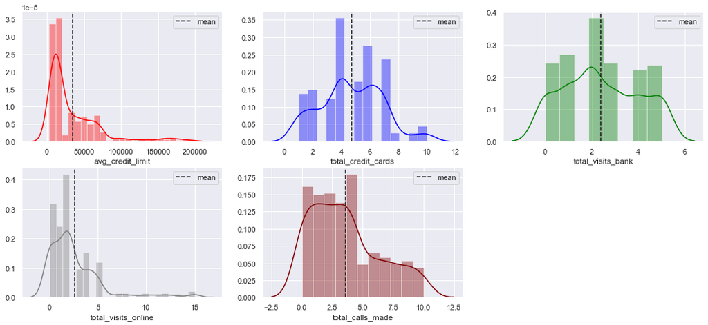

```python
# All attribute values appear to be numeric and continuous.
# Let's look at the distributions of these attibutes individually.

# Colors for plots
plot_colors = ['red', 'blue', 'green', 'grey', 'maroon']

# Plot univariate distributions
plt.figure(figsize=(18,12))
for idx, col in enumerate(data_df.columns):
    plt.subplot(3, 3, idx+1)
    sns.distplot(data_df[col], color=plot_colors[idx])
    plt.axvline(data_df[col].mean(), linestyle="dashed", label="mean", color="k")
    plt.legend(loc="best")
```

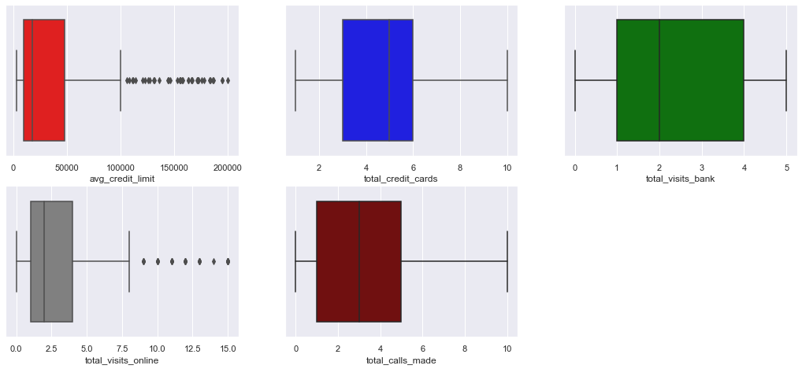

```python
# Let's look at the distribution and IQRs for the attributes individually
plt.figure(figsize= (18,12))
for idx, col in enumerate(data_df.columns):
    plt.subplot(3, 3, idx+1)
    sns.boxplot(x=data_df[col], color=plot_colors[idx]);
    idx += 1
```

```python
# Let's look at the skewness for variables
pd.DataFrame({'Skewness Value': [skew(data_df[var]) for var in data_df.columns]}, index=data_df.columns).T
```

|  | avg_credit_limit | total_credit_cards | total_visits_bank | total_visits_online | total_calls_made |
| --- | --- | --- | --- | --- | --- |
| Skewness Value | 2.197387 | 0.14455 | 0.141573 | 2.220545 | 0.657407 |

#### *Observations with EDA*:

- All attributes are numerical.
- **avg_credit_limit**: This attribute indicates the average credit card limits of the customers. Most of the data values are between 10000 to 50000. The mean is higher then the 50th percentile value and is considerably right skewed. There are considerable outliers which should be treated.
- **total_credit_cards**: This attribute indicates the total number of credit cards owned by a customer. The distribution seems quite normal with about 5 groups for values. The mean and 50 percentile value have little difference. There is little skewness observed here.
- **total_visits_bank**: These are visits to the bank by the customers in person. The distribution seems fairly normal. There seems to be three peaks in the distribution, indicating three groups. The skewness level is fairly low.
- **total_visits_online**: Assuming these are the requests for online banking. The distribution is quite skewed, with majority of the values between 0 and 5. There are some outliers observed, with which can work.
- **total_calls_made**: This attribute indicates total number of support calls made by a customer. The distribution seems fairly normal. The two peaks indicate two majority groups of values in the data. Some skewness in the data is observed.
- Based on the peaks in the distributions of these attributes, it seems 3 to 5 clusters should be good to get good segmentation across the customer data. Let's see.

#### Data Preprocessing

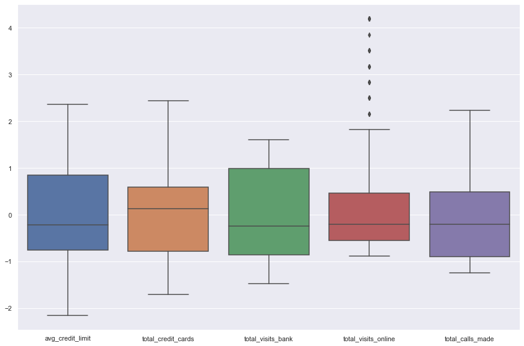

```python
# Let's remove duplicates
credit_df = data_df.drop_duplicates(keep='last')

# Create copy for scaling data
scaled_df = credit_df.copy(deep=True)

# Get avg_credit_limit in log scale as teh values have a higher range.
scaled_df['avg_credit_limit'] = np.log(scaled_df['avg_credit_limit'])

# There are few outliers with total_visits_online, but they should have negligible impact on the clustering alogirthms,
# as we will be considering the IQRs for segmentations.

# Let's scale the attributes
scaled_df = scaled_df.apply(zscore)

# Let's look at the IQRs using boxplots of all variables together with scaled data
plt.figure(figsize=(15, 10))
sns.boxplot(data=scaled_df);
```

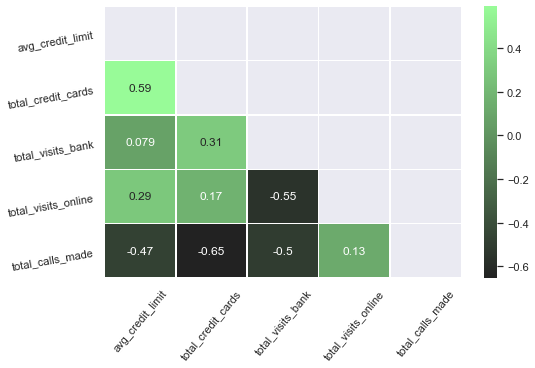

```python
# Let's visualize heatmap for the co-relation between attributes.
corr_df = scaled_df.corr()

# Create a mask to hide upper triangle of repeated values
upper_tri_mask = np.zeros_like(corr_df, dtype=np.bool)
upper_tri_mask[np.triu_indices_from(upper_tri_mask)] = True

# Draw the heatmap
plt.figure(figsize=(8,5))
pal = sns.dark_palette("palegreen", as_cmap=True)
pop_hmap = sns.heatmap(corr_df, mask=upper_tri_mask, annot=True, cmap=pal, linewidths=.5)
pop_hmap.set_xticklabels(pop_hmap.get_xticklabels(), rotation=50)
pop_hmap.set_yticklabels(pop_hmap.get_yticklabels(), rotation=10)
plt.show()
```

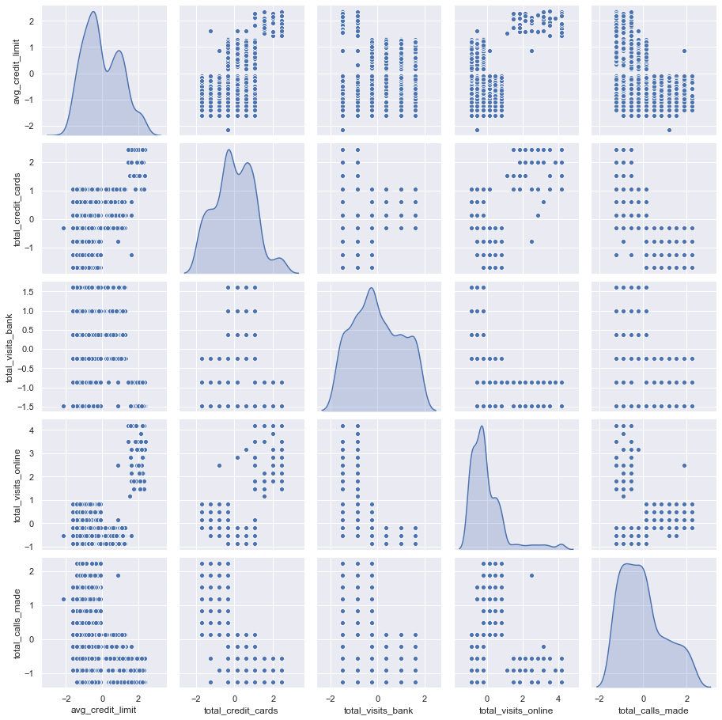

```python
# Let's look at the pair wise relation ships between independent and dependent variables with scaled data
sns.pairplot(scaled_df, diag_kind='kde');
```

#### *Observations on data scaling, correlation and pair plots*:

- Applying zcore to data tells how many standard deviations far a data point is from the mean and unifies their scale. This will be very important for clustering as the algorithms depend on the distance between data points, and will not be dominated by any single attribute because of its scale.
- There is good positive correlation between average_credit_limit and total_credit_cards. These attributes together may help determine a segment of customers.
- Also there is good negative correlation between total_credit_cards and total_calls_made. These attributes may lie in different segments.
- There is negative correlation between total_visits_online and total_visits_bank. These attributes may also help determine different segments of customers.
- Based on the peaks observed in the plot along the diagonal, 3, 4 or 5 clusters should be good to get good segmentation across the data provided.

```python
# Before we proceed, let's have a utility function to print the results from clustering algorithms,
# like number of records in a cluster, Q1, median and Q3 quartiles per cluster, etc.

# Note: credit_df is the original data and scaled_df is the scaled data.

# Store Silhouette score for later comaprison
silhouette_score_map = {}

def get_clustering_results(algo='kmeans', num_clusters=3, linkage_method='average', dendrogram_dist=3.25,
                           dist_metric='euclidean', show_box_plots=True):
    ''' Method to get clustering results
        algo            - Clustering algorithm: kmeans or hierarchical
        num_clusters    - Number of clsuters for kmeans clustering
        linkage_method  - Linkage method for hierarchical clustering
        dendrogram_dist - Dendrogramic distance to get certain number of clusters for hierarchical clustering
        dist_metric     - Distance metric for hierarchical clustering
        show_box_plots  - Indicator for showing box plots. Draw them if True.
    '''
    silhoutte_score = None
    cluster_labels = None
    silhouette_score_key = algo

    if algo == 'kmeans':
        # Get cluster labels using KMeans clustering
        kmeans_model = KMeans(random_state=SEED, n_clusters=num_clusters)
        cluster_labels = kmeans_model.fit_predict(scaled_df)
        silhouette_score_key += " " + str(num_clusters) + " Clusters"
        print("K-means clustering results for {0} clusters:".format(num_clusters))

    elif algo == 'hierarchical':
        # Get cluster labels using hierarchical clustering
        Z = linkage(scaled_df, metric=dist_metric, method=linkage_method, optimal_ordering=True)
        cluster_labels = fcluster(Z, t=dendrogram_dist, criterion='distance')
        clusters = max(cluster_labels)
        silhouette_score_key += " " + linkage_method.upper() + " with " + str(clusters) + " Clusters"
        print("Hierarchical clustering results for {0} linkage method with {1} clusters:".
              format(linkage_method, clusters))

    else:
        print("Incorrect clustering algorithm!")
        return

    # Print silhouette score
    silhoutte_score = round(silhouette_score(scaled_df, cluster_labels), 3)
    print('Silhouette Score: ', silhoutte_score)

    # Update silhouette score map
    silhouette_score_map[silhouette_score_key] = silhoutte_score

    # Get counts, Q1, median and Q3 quartiles, per cluster
    credit_df['Cluster'] = cluster_labels
    counts_df = credit_df.groupby('Cluster').count().sort_index()
    q1_df     = credit_df.groupby('Cluster').quantile(0.25).round(2).sort_index()
    median_df = credit_df.groupby('Cluster').median().round(2).sort_index()
    q3_df     = credit_df.groupby('Cluster').quantile(0.75).round(2).sort_index()

    # Create data frames for results
    summary_dict = {}
    for col in scaled_df.columns.to_list():
        summary_dict[col] = list(zip(q1_df[col].values, median_df[col].values, q3_df[col].values))
    summary_df = pd.DataFrame(summary_dict, index=median_df.index)
    counts_df.index.name = 'Counts per cluster'
    summary_df.index.name = '(Q1, Median, Q3) per cluster'

    # Display data frames
    disp.display(counts_df)
    disp.display(summary_df)

    # If indicated, draw box plots for clusters using scaled data
    if show_box_plots:
        scaled_copy = scaled_df.copy(deep=True)
        scaled_copy['Cluster'] = cluster_labels
        scaled_copy.boxplot(by='Cluster', layout=(2,3), figsize=(18,10));
```

### K-Means Clustering

Now, we will use K-Means clustering to group data based on their attribute. First, we need to determine the optimal number of groups. For that we conduct the knee test (elbow plot) to see where the knee happens.

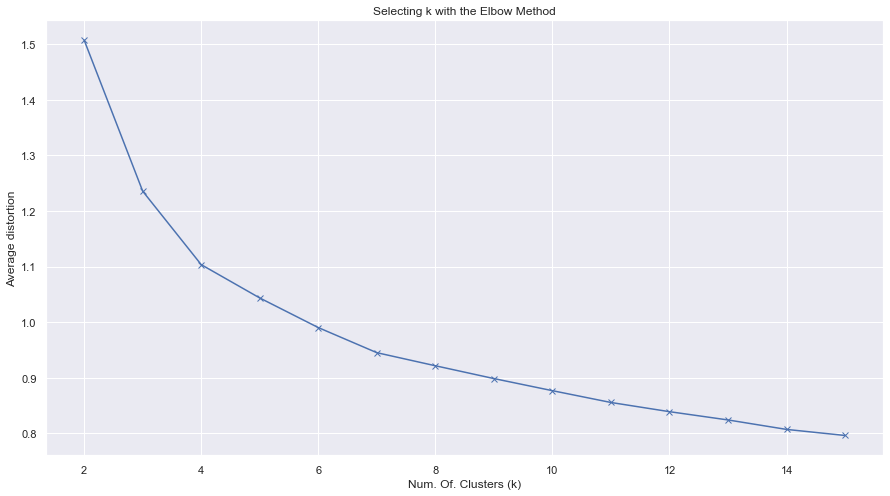

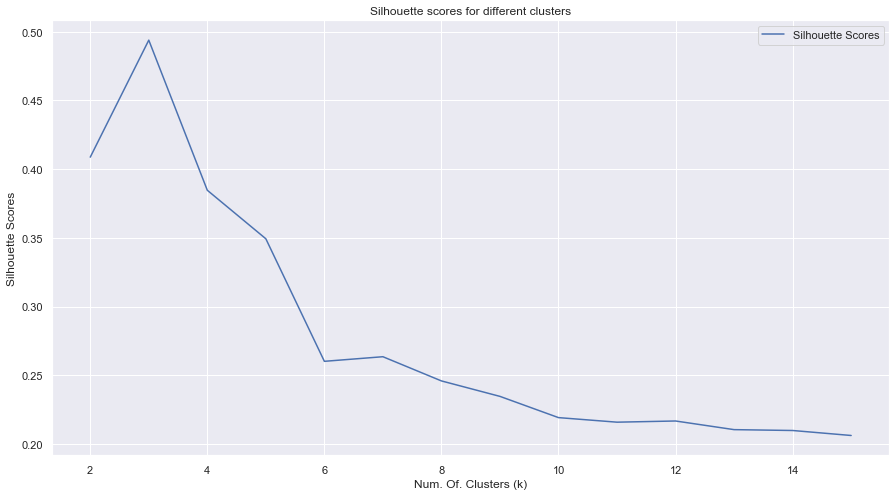

```python
# Let's consider 2 to 15 clusters for the knee test
clusters=range(2,16)

# Min distortions to be stored for the plot
meanDistortions=[]

# Silhouette scores to be stored for plotting.
silhouette_scores=[]

# Get min distortions and silhouette scores for various number of clusters.
for k in clusters:
    model = KMeans(random_state=SEED, n_clusters=k)
    prediction = model.fit_predict(scaled_df)
    mean_dist = sum(np.min(cdist(scaled_df, model.cluster_centers_, 'euclidean'), axis=1)) / scaled_df.shape[0]
    meanDistortions.append(mean_dist)
    silhouette_scores.append(silhouette_score(scaled_df, prediction))

# Elbow plot
plt.figure(figsize=(15,8))
plt.plot(clusters, meanDistortions, 'bx-');
plt.xlabel('Num. Of. Clusters (k)')
plt.ylabel('Average distortion')
plt.title('Selecting k with the Elbow Method')
plt.show()

# Let's look at the corresponding Silhouette scores
pd.DataFrame({'Silhouette Scores': silhouette_scores}, index = clusters).plot(figsize=(15,8));
plt.xlabel('Num. Of. Clusters (k)')
plt.ylabel('Silhouette Scores')
plt.title('Silhouette scores for different clusters')
plt.show()
```

#### *Observations for knee test*:

- There seems to be a "knee" at four clusters.
- There also seems to be "knee" at three and seven clusters.
- Three and four clusters have considerable Silhouette scores, but seven clusters has lower silhouette score.
- Let's consider 3, 4 and 5 as potential number of clusters for further analysis.

```
K-means clustering results for 3 clusters:
Silhouette Score:  0.494
```

| Counts per cluster | avg_credit_limit | total_credit_cards | total_visits_bank | total_visits_online | total_calls_made |
| --- | --- | --- | --- | --- | --- |
| 0 | 50 | 50 | 50 | 50 | 50 |
| 1 | 222 | 222 | 222 | 222 | 222 |
| 2 | 377 | 377 | 377 | 377 | 377 |

| (Q1, Median, Q3) per cluster | avg_credit_limit | total_credit_cards | total_visits_bank | total_visits_online | total_calls_made |
| --- | --- | --- | --- | --- | --- |
| 0 | (108750.0, 145500, 170000.0) | (8.0, 9, 10.0) | (0.0, 1, 1.0) | (8.0, 11, 13.0) | (0.0, 1, 2.0) |
| 1 | (8000.0, 12000, 16000.0) | (1.0, 2, 3.0) | (0.0, 1, 2.0) | (2.0, 4, 4.0) | (5.0, 7, 9.0) |
| 2 | (14000.0, 32000, 52000.0) | (4.0, 6, 6.0) | (3.0, 3, 5.0) | (0.0, 1, 2.0) | (1.0, 2, 3.0) |

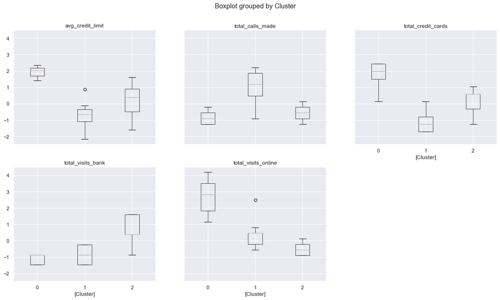

```python
# Let's look at K-means clustering results with three clusters
get_clustering_results(algo='kmeans', num_clusters=3)
```

#### *Observations on segmentation*:

- Cluster 0: Customers in this cluster have high credit card limits (108K - 170K) and highest total number of credit cards (8-10). They have the lowest in person bank visits and highest online visits. They also have the lowest calls made. This cluster has fewer customers (50).
- Cluster 1: These are the customers with lowest credit card limits (8K - 16K) and have the least number of credit cards (1-3). They also have lower in person visits to the bank and moderate online visits. However, they have the highest number of calls to the bank. This group has considerable number of customers, over 200.
- Cluster 2: This is group of customers with moderate credit card limits (14K- 52K) and have moderate number of credit cards (4-6). They have the highest in person bank visits and lowest online visits. Also, they have lower phone calls to the bank. This group has highest number of customers, over 350.

```
K-means clustering results for 4 clusters:
Silhouette Score:  0.385
```

| Counts per cluster | avg_credit_limit | total_credit_cards | total_visits_bank | total_visits_online | total_calls_made |
| --- | --- | --- | --- | --- | --- |
| 0 | 217 | 217 | 217 | 217 | 217 |
| 1 | 220 | 220 | 220 | 220 | 220 |
| 2 | 162 | 162 | 162 | 162 | 162 |
| 3 | 50 | 50 | 50 | 50 | 50 |

| (Q1, Median, Q3) per cluster | avg_credit_limit | total_credit_cards | total_visits_bank | total_visits_online | total_calls_made |
| --- | --- | --- | --- | --- | --- |
| 0 | (37000.0, 49000, 64000.0) | (4.0, 6, 7.0) | (2.0, 3, 4.0) | (0.0, 1, 2.0) | (1.0, 2, 3.0) |
| 1 | (8000.0, 12000, 16000.0) | (1.0, 2, 3.0) | (0.0, 1, 2.0) | (2.75, 4, 4.25) | (5.0, 7, 9.0) |
| 2 | (8000.0, 12000, 17000.0) | (4.0, 6, 6.0) | (3.0, 4, 5.0) | (0.0, 1, 2.0) | (1.0, 2, 3.0) |
| 3 | (108750.0, 145500, 170000.0) | (8.0, 9, 10.0) | (0.0, 1, 1.0) | (8.0, 11, 13.0) | (0.0, 1, 2.0) |

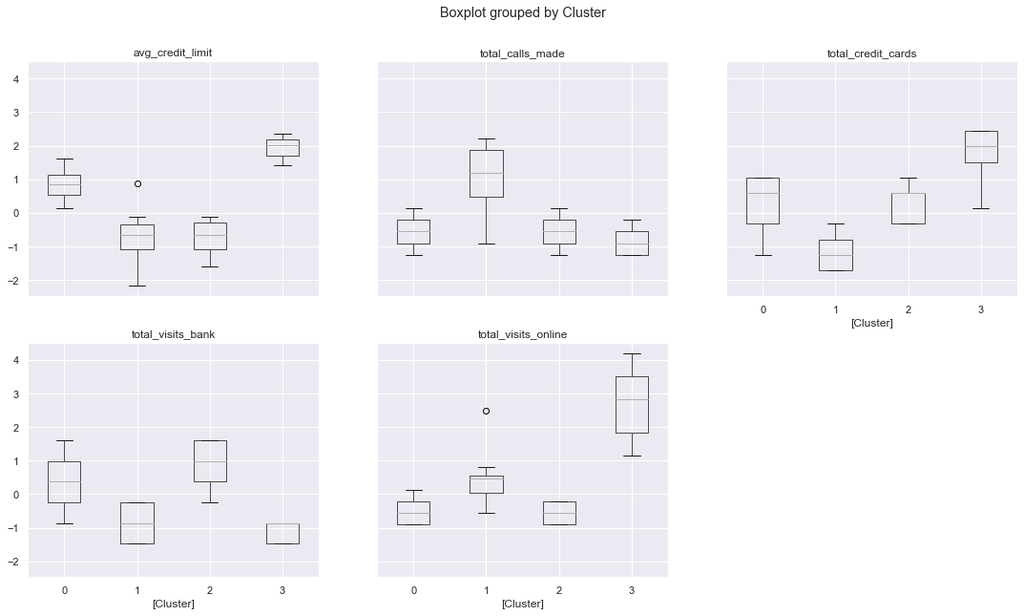

```python
# Let's look at K-means clustering results with four clusters
get_clustering_results(algo='kmeans', num_clusters=4)
```

#### *Observations on segmentation*:

- Cluster 0: This is the group of customers with moderate credit card limits and moderate number of credit cards (4-7). They have moderate in person visits but least online visits to the bank. They also have lower phone calls made to the bank. According to clustering there are over 200 such customers.
- Cluster 1: These are the customers with lowest credit card limits (8K - 16K) and have the least number of credit cards (1-3). They also have lower in person visits to the bank but considerable online visits. However, they have the highest number of calls. This group has considerable number of customers, over 200.
- Cluster 2: These are also the customers with lowest credit card limits (8K - 16K) however, they have considerable number of credit cards (4-6). They also have considerable in person visits to the bank but lowest online visits. They also have lower phone calls made to the bank. This group has good number of customers, over 150.
- Cluster 3: They have highest credit card limits (108K - 170K) and highest number of credit cards (8-10). They have the lowest in person bank visits and highest online visits. They also have the lowest calls made to the bank. This cluster has fewer customers (50). This group is also observed with three clusters segmentation.

```
K-means clustering results for 5 clusters:
Silhouette Score:  0.349
```

| Counts per cluster | avg_credit_limit | total_credit_cards | total_visits_bank | total_visits_online | total_calls_made |
| --- | --- | --- | --- | --- | --- |
| 0 | 143 | 143 | 143 | 143 | 143 |
| 1 | 130 | 130 | 130 | 130 | 130 |
| 2 | 219 | 219 | 219 | 219 | 219 |
| 3 | 50 | 50 | 50 | 50 | 50 |
| 4 | 107 | 107 | 107 | 107 | 107 |

| (Q1, Median, Q3) per cluster | avg_credit_limit | total_credit_cards | total_visits_bank | total_visits_online | total_calls_made |
| --- | --- | --- | --- | --- | --- |
| 0 | (8000.0, 11000, 15000.0) | (4.0, 6, 6.0) | (3.0, 4, 5.0) | (0.0, 1, 2.0) | (1.0, 2, 3.0) |
| 1 | (34250.0, 49000, 62750.0) | (4.0, 6, 6.0) | (2.0, 2, 3.0) | (0.0, 1, 2.0) | (1.0, 2, 3.0) |
| 2 | (8000.0, 12000, 16000.0) | (1.0, 2, 3.0) | (0.0, 1, 2.0) | (3.0, 4, 4.5) | (5.0, 7, 9.0) |
| 3 | (108750.0, 145500, 170000.0) | (8.0, 9, 10.0) | (0.0, 1, 1.0) | (8.0, 11, 13.0) | (0.0, 1, 2.0) |
| 4 | (36000.0, 43000, 61500.0) | (5.0, 6, 7.0) | (4.0, 5, 5.0) | (0.0, 1, 2.0) | (1.0, 2, 3.0) |

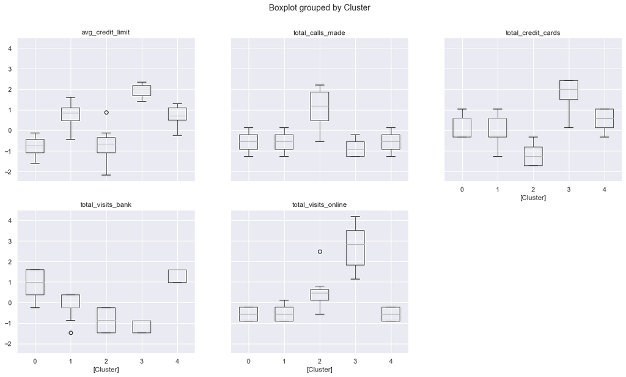

```python
# Let's look at KMeans clustering with five clusters
get_clustering_results(algo='kmeans', num_clusters=5)
```

#### *Observations on segmentation*:

- For 5, clusters the segmentation is not very clear. There is a lot of overlap in the IQRs of mulitiple attributes, and hence it would be difficult to clearly distinguish among the groups.
- The group of 50 customers with high credit limits and higher number of credit cards, has been identified. This group is is also observed with segmentation using 3 and 4 clusters.

## Hierarchical Clustering

In this section we perform Hierarchical Clustering using scipy.cluster.hierarchy. We chose the best linkage method using dendrogram and cophenetic correlation and analyze the clusters using box plots.

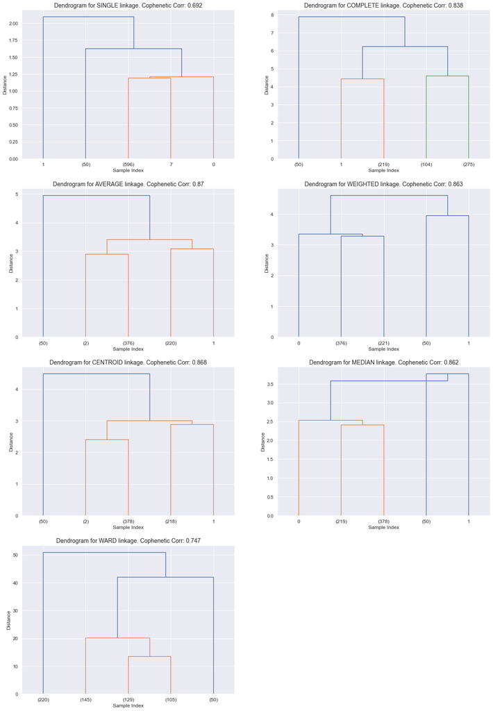

```python
# Linkage methods to be selected
# Reference: https://docs.scipy.org/doc/scipy/reference/generated/scipy.cluster.hierarchy.linkage.html
linkage_methods = ['single', 'complete', 'average', 'weighted', 'centroid', 'median', 'ward']

# Distance metric
dist_metric='euclidean'

# Plot index
idx=1

# Let's plot dendrograms and calculate cophenetic correlations for above linkage methods
plt.figure(figsize=(20,30))
for link in linkage_methods:
    # Perform hierarchical clustering
    Z = linkage(scaled_df, metric=dist_metric, method=link, optimal_ordering=True)

    # Compute the cophenetic correlation
    c, _ = cophenet(Z , pdist(scaled_df))

    # Let's look at the dendrogram
    plt.subplot(4, 2, idx)
    plt.title('Dendrogram for ' + link.upper() + ' linkage. Cophenetic Corr: ' + str(round(c, 3)), fontsize=14)
    plt.xlabel('Sample Index')
    plt.ylabel('Distance')
    dendrogram(Z, p=5, truncate_mode='lastp')
    idx += 1
```

#### Observations on dendrograms and cophenetic correlation:

- Average method has the highest cophenetic correlation.
- The average method with four clusters will yield uneven segmentation with one of the groups having just one record. However, it will yield better segmentation with three clusters.
- The ward has lower cophenetic correlation but will yield better segmentation using three and four clusters.

```python
# In order to select best linkage method, Let's further look at the silhouette scores for average and ward methods

# Map of linkage method to its dedrogramic distances for 2, 3, 4 and 5 clsuters
link_dist_map = {
    'average' : [4, 3.25, 3.05, 2.75],
    'ward': [45, 30, 18, 12]
}

# Calculate Silhouette scores for above methods and number of clusters
results_dict = {}
for link, distances in link_dist_map.items():
    Z = linkage(scaled_df, metric='euclidean', method=link, optimal_ordering=True)
    for d in distances:
        clusters = fcluster(Z, t=d, criterion='distance')
        score = silhouette_score(scaled_df, clusters)
        results_dict[link + ' linkage with ' + str(max(clusters)) + ' clusters'] = round(score,3)

pd.DataFrame(results_dict, index=['Silhouette Score']).T
```

|  | Silhouette Score |
| --- | --- |
| average linkage with 2 clusters | 0.500 |
| average linkage with 3 clusters | 0.494 |
| average linkage with 4 clusters | 0.463 |
| average linkage with 5 clusters | 0.387 |
| ward linkage with 2 clusters | 0.409 |
| ward linkage with 3 clusters | 0.494 |
| ward linkage with 4 clusters | 0.367 |
| ward linkage with 5 clusters | 0.336 |

#### *Observations on Silhouette scores for average and ward method*:

- Average method for three clusters has the same silhouette score as that of ward method for three clusters.
- Average method for four clusters doesn't yield good segmentation in terms of counts per group. However still has better silhouette score.

#### Let's consider average method with three clusters and ward method with three and four clusters for further analysis

```
Hierarchical clustering results for average linkage method with 3 clusters:
Silhouette Score:  0.494
```

| Counts per cluster | avg_credit_limit | total_credit_cards | total_visits_bank | total_visits_online | total_calls_made |
| --- | --- | --- | --- | --- | --- |
| 1 | 50 | 50 | 50 | 50 | 50 |
| 2 | 378 | 378 | 378 | 378 | 378 |
| 3 | 221 | 221 | 221 | 221 | 221 |

| (Q1, Median, Q3) per cluster | avg_credit_limit | total_credit_cards | total_visits_bank | total_visits_online | total_calls_made |
| --- | --- | --- | --- | --- | --- |
| 1 | (108750.0, 145500, 170000.0) | (8.0, 9, 10.0) | (0.0, 1, 1.0) | (8.0, 11, 13.0) | (0.0, 1, 2.0) |
| 2 | (14000.0, 32000, 52000.0) | (4.0, 6, 6.0) | (3.0, 3, 4.75) | (0.0, 1, 2.0) | (1.0, 2, 3.0) |
| 3 | (8000.0, 12000, 16000.0) | (1.0, 2, 3.0) | (0.0, 1, 2.0) | (2.0, 4, 4.0) | (5.0, 7, 9.0) |

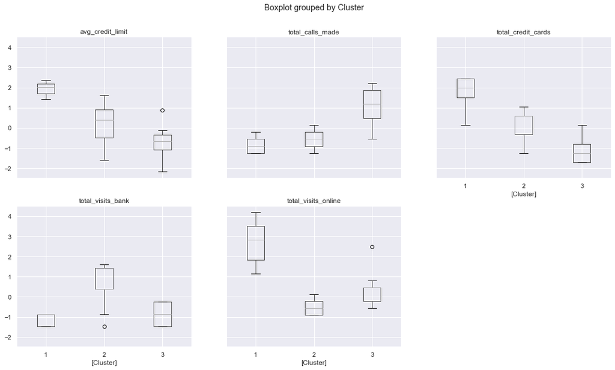

```python
# Let's look at hierarchical clustering with average linkage method and three clusters.
get_clustering_results(algo='hierarchical', linkage_method='average', dendrogram_dist=3.25)
```

#### *Observations on segmentation*:

- Cluster 1: They have high credit card limits (108K - 170K) and highest total number of credit cards (8-10). They have the lowest in person bank visits and highest online visits. They also have the lowest calls made and this cluster has fewer customers (~50).
- Cluster 2: This is group of customers with moderate credit card limits (14K- 52K) and have considerable number of credit cards (4-6). They have the highest in person bank visits and lowest online visits. Also, they have lower phone calls to the bank. This group has considerable number of customers, over 350.
- Cluster 3: These are the customers with lowest credit card limits (8K - 16K) and have the least number of credit cards (1-3). They also have lower in person visits to the bank and moderate online visits. However, they have the highest number of phone calls to the bank. This group has considerable number of customers, over 200.
- The clustering results are very similar to k-means clustering with 3 clusters.

```
Hierarchical clustering results for ward linkage method with 3 clusters:
Silhouette Score:  0.494
```

| Counts per cluster | avg_credit_limit | total_credit_cards | total_visits_bank | total_visits_online | total_calls_made |
| --- | --- | --- | --- | --- | --- |
| 1 | 220 | 220 | 220 | 220 | 220 |
| 2 | 379 | 379 | 379 | 379 | 379 |
| 3 | 50 | 50 | 50 | 50 | 50 |

| (Q1, Median, Q3) per cluster | avg_credit_limit | total_credit_cards | total_visits_bank | total_visits_online | total_calls_made |
| --- | --- | --- | --- | --- | --- |
| 1 | (8000.0, 12000, 16000.0) | (1.0, 2, 3.0) | (0.0, 1, 2.0) | (2.75, 4, 4.25) | (5.0, 7, 9.0) |
| 2 | (13500.0, 32000, 52000.0) | (4.0, 6, 6.0) | (2.5, 3, 4.5) | (0.0, 1, 2.0) | (1.0, 2, 3.0) |
| 3 | (108750.0, 145500, 170000.0) | (8.0, 9, 10.0) | (0.0, 1, 1.0) | (8.0, 11, 13.0) | (0.0, 1, 2.0) |

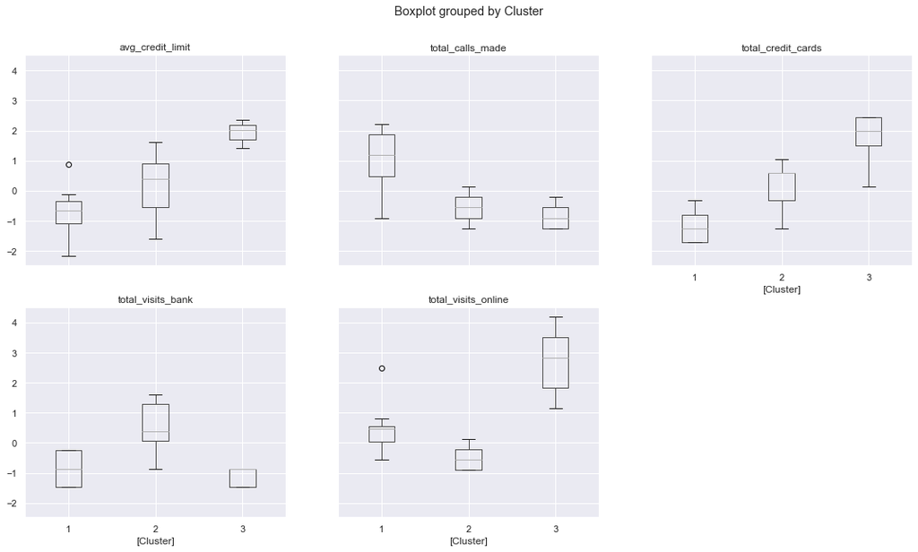

```python
# Let's look at hierarchical clustering with ward linkage method and three clusters
get_clustering_results(algo='hierarchical', linkage_method='ward', dendrogram_dist=30)
```

#### *Observations on segmentation*:

The ward linkage method with 3 clusters yields similar results to that of average linkage method and k-means clustering with 3 clusters.

```
Hierarchical clustering results for ward linkage method with 4 clusters:
Silhouette Score:  0.367
```

| Counts per cluster | avg_credit_limit | total_credit_cards | total_visits_bank | total_visits_online | total_calls_made |
| --- | --- | --- | --- | --- | --- |
| 1 | 220 | 220 | 220 | 220 | 220 |
| 2 | 145 | 145 | 145 | 145 | 145 |
| 3 | 234 | 234 | 234 | 234 | 234 |
| 4 | 50 | 50 | 50 | 50 | 50 |

| (Q1, Median, Q3) per cluster | avg_credit_limit | total_credit_cards | total_visits_bank | total_visits_online | total_calls_made |
| --- | --- | --- | --- | --- | --- |
| 1 | (8000.0, 12000, 16000.0) | (1.0, 2, 3.0) | (0.0, 1, 2.0) | (2.75, 4, 4.25) | (5.0, 7, 9.0) |
| 2 | (8000.0, 11000, 16000.0) | (4.0, 5, 6.0) | (2.0, 3, 4.0) | (0.0, 1, 2.0) | (1.0, 2, 3.0) |
| 3 | (36000.0, 48000, 62750.0) | (5.0, 6, 7.0) | (3.0, 4, 5.0) | (0.0, 1, 2.0) | (1.0, 2, 3.0) |
| 4 | (108750.0, 145500, 170000.0) | (8.0, 9, 10.0) | (0.0, 1, 1.0) | (8.0, 11, 13.0) | (0.0, 1, 2.0) |

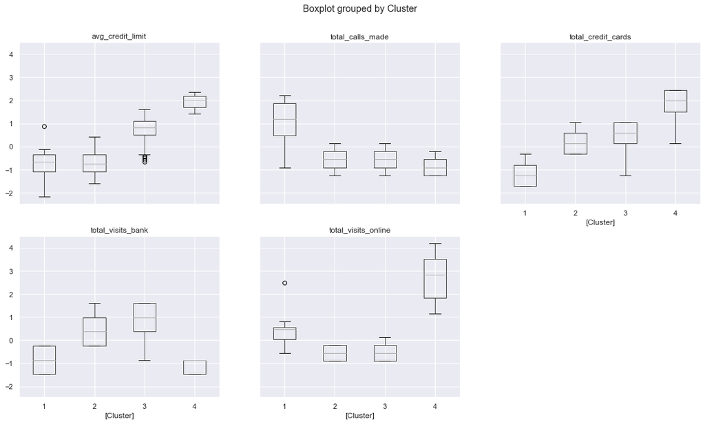

```python
# Let's look at hierarchical clustering with four clusters and ward linkage method
get_clustering_results(algo='hierarchical', linkage_method='ward', dendrogram_dist=18)
```

#### *Observations*:

Hierarchical clustering results of ward linkage method and four clusters are very similar to that of k-means with four clusters.

## Silhouette Scores for K-Means and Hierarchical Clustering

So far we have observed that for k-means clustering with three and four clusters and hierarchical clustering with average (with three clusters) and ward linkage (with three and four clusters) have given good segmentation. Let's consider their silhouette scores.

```python
pd.DataFrame(silhouette_score_map, index=['Average Silhouette Score']).T
```

|  | Average Silhouette Score |
| --- | --- |
| kmeans 3 Clusters | 0.494 |
| kmeans 4 Clusters | 0.385 |
| kmeans 5 Clusters | 0.349 |
| hierarchical AVERAGE with 3 Clusters | 0.494 |
| hierarchical WARD with 3 Clusters | 0.494 |
| hierarchical WARD with 4 Clusters | 0.367 |

#### *Observations*:

- K-Means and hierarchical clustering with three clusters have yielded the best Silhouette score (~0.5), indicating good clustering performance.
- K-Means clustering with four and five clusters have not yielded good segmentation performance as such.
- Hierarchical clustering (with average and ward linkage methods) with three clusters have yielded the best Silhouette scores at par with that of K-Means clustering. This indicates similar performance as that of K-Means.
- Hierarchical clustering (with ward linkage method) with four clusters yielded low Silhouette score indicating subordinate clustering performance.

## Comparison Between K-Means and Hierarchical Clusters

Let's again look at the customer segmentation with K-Means and Hierarchical clustering with three clusters

```python
# Let's look at KMeans results clustering with three clusters
get_clustering_results(algo='kmeans', num_clusters=3, show_box_plots=False)
```

```
K-means clustering results for 3 clusters:
Silhouette Score:  0.494
```

| Counts per cluster | avg_credit_limit | total_credit_cards | total_visits_bank | total_visits_online | total_calls_made |
| --- | --- | --- | --- | --- | --- |
| 0 | 50 | 50 | 50 | 50 | 50 |
| 1 | 222 | 222 | 222 | 222 | 222 |
| 2 | 377 | 377 | 377 | 377 | 377 |

| (Q1, Median, Q3) per cluster | avg_credit_limit | total_credit_cards | total_visits_bank | total_visits_online | total_calls_made |
| --- | --- | --- | --- | --- | --- |
| 0 | (108750.0, 145500, 170000.0) | (8.0, 9, 10.0) | (0.0, 1, 1.0) | (8.0, 11, 13.0) | (0.0, 1, 2.0) |
| 1 | (8000.0, 12000, 16000.0) | (1.0, 2, 3.0) | (0.0, 1, 2.0) | (2.0, 4, 4.0) | (5.0, 7, 9.0) |
| 2 | (14000.0, 32000, 52000.0) | (4.0, 6, 6.0) | (3.0, 3, 5.0) | (0.0, 1, 2.0) | (1.0, 2, 3.0) |

```python
# Let's look at hierarchical clustering with average linkage method and three clusters.
get_clustering_results(algo='hierarchical', linkage_method='average', dendrogram_dist=3.25, show_box_plots=False)
```

```
Hierarchical clustering results for average linkage method with 3 clusters:
Silhouette Score:  0.494
```

| Counts per cluster | avg_credit_limit | total_credit_cards | total_visits_bank | total_visits_online | total_calls_made |
| --- | --- | --- | --- | --- | --- |
| 1 | 50 | 50 | 50 | 50 | 50 |
| 2 | 378 | 378 | 378 | 378 | 378 |
| 3 | 221 | 221 | 221 | 221 | 221 |

| (Q1, Median, Q3) per cluster | avg_credit_limit | total_credit_cards | total_visits_bank | total_visits_online | total_calls_made |
| --- | --- | --- | --- | --- | --- |
| 1 | (108750.0, 145500, 170000.0) | (8.0, 9, 10.0) | (0.0, 1, 1.0) | (8.0, 11, 13.0) | (0.0, 1, 2.0) |
| 2 | (14000.0, 32000, 52000.0) | (4.0, 6, 6.0) | (3.0, 3, 4.75) | (0.0, 1, 2.0) | (1.0, 2, 3.0) |
| 3 | (8000.0, 12000, 16000.0) | (1.0, 2, 3.0) | (0.0, 1, 2.0) | (2.0, 4, 4.0) | (5.0, 7, 9.0) |

#### *Observations*:

Let's compare the clusters formed by K-Means and Hierarchical clustering.

**Cluster 0 of K-Means is similar to Cluster 1 of Hierarchical**: Customers in this cluster have high credit card limits (108K - 170K) and highest total number of credit cards (8-10). They have the lowest in person bank visits and highest online visits. They also have the lowest calls made. This cluster has fewer customers (50).

**Cluster 1 of K-Means is similar to Cluster 3 of Hierarchical**: These are the customers with lowest credit card limits (8K - 16K) and have the least number of credit cards (1-3). They also have lower in person visits to the bank and moderate online visits. However, they have the highest number of calls. This group has considerable number of customers, over 200.

**Cluster 2 of K-Means is similar to Cluster 2 of Hierarchical**: This is group of customers with moderate credit card limits (14K- 52K) and have considerable number of credit cards (4-6). They have the highest in person bank visits and lowest online visits. Also, they have lower phone calls to the bank. This group has highest number of customers, over 350.

## Analyzing Clusters - Finding Answers to Key Questions

The best average Silhouette scores from both clustering algorithms are identical. As seen in the previous section, the segmentation achieved by both algorithms is very similar.

### Key Questions:

**1. How many different segments of customers are there?**

Broadly, there are three different segments of customers that can be considered.

**2. How are these segments different from each other?**

The three segments are different from each other in following ways:

*Segment 1: Customers with high credit limits*: These are also the customers with highest number of total credit cards. They rarely visit the bank in person and often visit the bank online. They rarely call bank support. They are lower in counts (about 50).

*Segment 2: Customers with moderate credit limits*: These are also the customers with moderate number of total credit cards. They frequently visit the bank in person and few times visit the bank online. They occasionally call the bank support.

*Segment 3: Customers with low credit limits*: These are also the customers with lowest number of credit cards. They visit the bank in person very less frequently but occasionally visits bank online. They call the bank support very often.

**3. What are your recommendations to the bank on how to better market to and service these customers?**

Segment 1 customers are fairly rich people who prefer more credit cards and also handle most of their bank related tasks online. They could be targeted online for marketing campaigns and products such as new credit cards, account upgrades, term deposits, credit card consolidations, going paperless, etc. Support service for these customers could be provided online and remotely as well, since they do not prefer visiting bank in person.

Segment 2 customers have moderate credit limits and moderate number of credit cards and prefer visiting bank in person and less online, so in person marketing campaigns would be useful. Also handling their support request in person would help. They do occasionally try to access the bank portal online, so persuading them to use the banking services online more would help in long term.

Segment 3 customers have the lowest credit limits and lower number of credit cards. They have moderate online visits. For marketing purpose they should be targeted more online. The bank can target them for additional credit cards, term deposit, etc. The bank should focus on supporting them better, as the have highest number of support calls.